# XML-Vignette

Group H

6/6/2019

# Introduction to XML

[(XML) Extensible Markup Language](https://www.geeksforgeeks.org/difference-between-json-and-xml/) is a markup language. The basic building block of an XML document is an element, defined by tags, uses tag structure to represent data items. It supports namespaces but doesn’t support arrays.It defines a set of rules for encoding documents in a format that is both human-readable and machine-readable thus it is less readable than JSON. It supports comments and various encoding. The design goals of XML focus on simplicity, generality, and usability across the Internet. XML is similar to other [markup languages](https://en.wikipedia.org/wiki/Markup_language) such as HTML, but offers more flexibility and customization. A key difference between HTML and XML is that HTML defines how data looks, while [XML defines what data is."](https://www.makeuseof.com/tag/xml-file-case-wondering/).

XML has found wide [application](https://www.ibm.com/support/knowledgecenter/en/ssw_ibm_i_71/rzamj/rzamjintrouses.htm):  
* Allows for creation of interactive webpages  
* Increases ease of returning useful web search results  
* Use, store, tramsmit, and display data across various devices  
* Increased accessability for data exchange across businesses and customers  
* Expresses metadata in a portable, resuable format

XML is [a good way to store data](https://searchmicroservices.techtarget.com/definition/XML-Extensible-Markup-Language) because XML data is known as self-describing or self-defining, meaning that the structure of the data is embedded with the data, thus when the data arrives there is no need to pre-build the structure to store the data; it is dynamically understood within the XML.

Comparison with JSON: [JSON (JavaScript Object Notation)](https://www.geeksforgeeks.org/difference-between-json-and-xml/) is a lightweight data-interchange format and is completely language independent. It is based on the JavaScript programming language to understand and generate. It is a way of representing objects. It doesn’t use end tag. It supports array but doesn’t support namespaces. Its files are very easy to read as compared to XML. It doesn’t support comments and supports only UTF-8 encoding. Both XML and JSON are self-describing and can be parsed and used by lots of programming languages.

# R Packages/functions for XML Data

“XML” package written by Duncan Temple Lang, it is available on CRAN-R and is one of the easier ways to parse, process and generate XML data with R. There are other packages such as `xml2()` and `xslt()`, some people on GitHub highly recommonded xml2() produced by Hadley Wickham, it has a simpler interface with great simplicity vs power balance and makes everything clean and tidy, but here we applied the traditional xml(). The xml file is read by R using the function **xmlParse()**, it is stored as a list in R. To handle the data effectively in large files we read the data in the xml file as a data frame by using function **xmlToDataFrame()**. Then we can process the data frame for data analysis.

# XML Data Set

The data set pertains to drug poisoning deaths at the U.S. and state level. The [data set](https://catalog.data.gov/dataset/drug-poisoning-mortality-u-s-and-state-trends-united-states-20022014) was published by the Centers for Disease Control and Prevention.

Estimates are collected based on the National Vital Statistics System multiple cause-of-death mortality files. Populations used for computing death rates for census years (2011-2015) are postcensal estimates based on the 2010 U.S. census, while for noncensus years (before 2010) population is revised using updated intercensal population estimates.

The selected demographic characteristics variables are “year”, “sex”, “age”, “race_hispanic_origin”, “state”, “deaths”, “population”, “crude_death_rate”, “standard_error_for_crude_rate”, “low_confidence_limit_for_crude_rate”, “upper_confidence_limit_for_crude_rate”, “us_crude_rate”,“us_age_adjusted_rate”.

# Exploratory Data Analysis

Data analysis to determine if a difference between sex and drug poisonings exists amongst all ages and all races. Conclusion: For all ages and races, females have a lower drug poisoning crude death rate than males.

| year | sex female | female death | female population | female crude death rate | sex male | male death | male population | male crude death rate | crude death rate (female - male) |
| --- | --- | --- | --- | --- | --- | --- | --- | --- | --- |
| 1999 | Female | 5591 | 142237347 | 3.9308 | Male | 11258 | 136802891 | 8.2294 | -4.2986 |
| 2000 | Female | 5852 | 143368343 | 4.0818 | Male | 11563 | 138053563 | 8.3757 | -4.2939 |
| 2001 | Female | 6736 | 145077463 | 4.643 | Male | 12658 | 139891492 | 9.0484 | -4.4054 |
| 2002 | Female | 8490 | 146394634 | 5.7994 | Male | 15028 | 141230559 | 10.6408 | -4.8414 |
| 2003 | Female | 9386 | 147679036 | 6.3557 | Male | 16399 | 142428897 | 11.5138 | -5.1581 |
| 2004 | Female | 10304 | 148977286 | 6.9165 | Male | 17120 | 143828012 | 11.9031 | -4.9866 |
| 2005 | Female | 11089 | 150319521 | 7.377 | Male | 18724 | 145197078 | 12.8956 | -5.5186 |
| 2006 | Female | 12532 | 151732647 | 8.2593 | Male | 21893 | 146647265 | 14.929 | -6.6697 |
| 2007 | Female | 13712 | 153166353 | 8.9524 | Male | 22298 | 148064854 | 15.0596 | -6.1072 |
| 2008 | Female | 13982 | 154604015 | 9.0437 | Male | 22468 | 149489951 | 15.0298 | -5.9861 |

[output cut: 7 more lines]

The boxplot below shows the crude death rates for females and males across all age groups, all races, and all years of data. It is evident from the boxplot that the crude death rates for males has a much larger range and is overall higher than that of females.

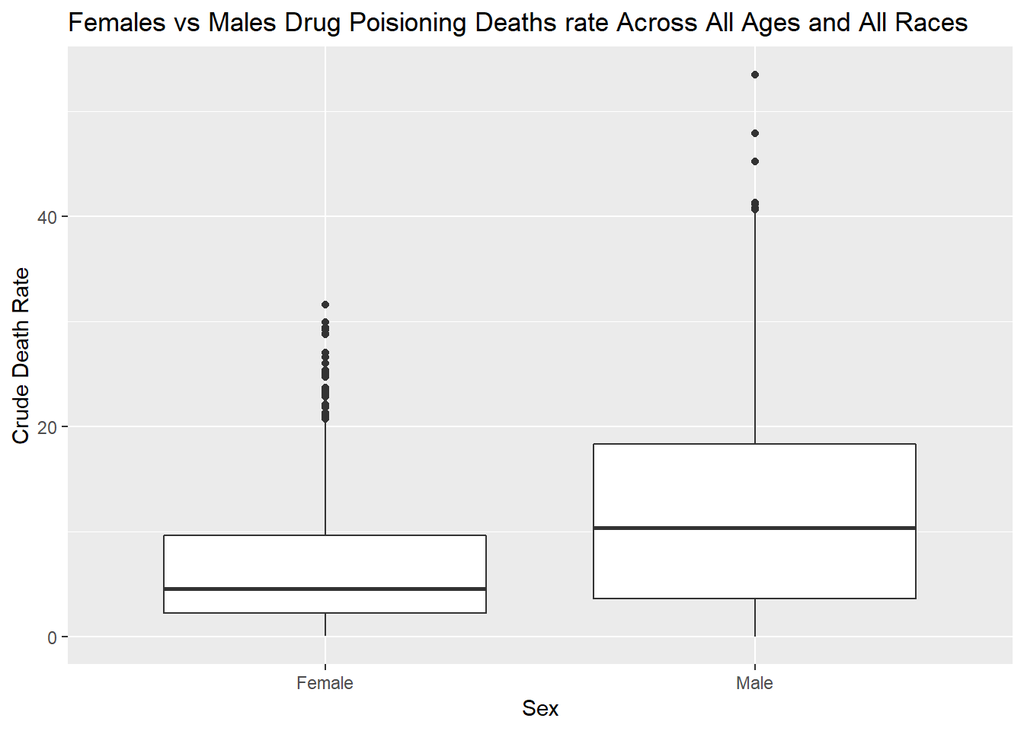

The first contingency table and bar plot below shows that across each indidivudal age grouping males have a higher average death rate than females for all races. The second contingency table and bar plot below shows that across each race males have a higher average death rate than females for all ages.

Average Death Rate for Females and Males Across all Age Groups

| sex | 15-24 years | 25-34 years | 35-44 years | 45-54 years | 55-64 years | 65-74 years | 75+ years | All Ages | Less than 15 years |
| --- | --- | --- | --- | --- | --- | --- | --- | --- | --- |
| Female | 3.941440 | 8.969443 | 15.91099 | 16.45307 | 11.23433 | 4.310711 | 3.295071 | 8.643067 | 0.1498429 |
| Male | 9.778136 | 24.582733 | 24.88774 | 25.96723 | 13.29394 | 4.639325 | 3.643162 | 15.310340 | 0.1966600 |

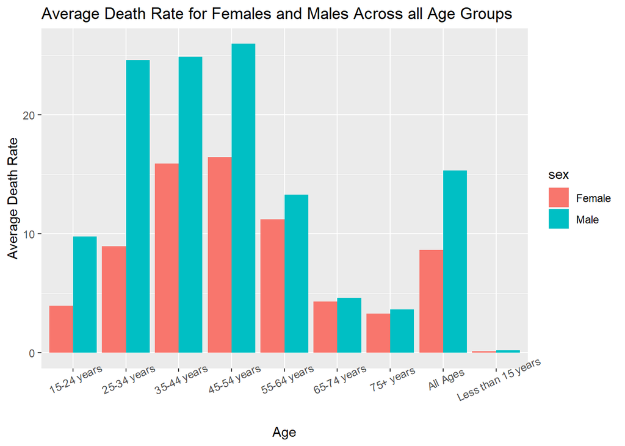

Average Death Rate for Females and Males Across all Races

| sex | All Races-All Origins | Hispanic | Non-Hispanic Black | Non-Hispanic White |
| --- | --- | --- | --- | --- |
| Female | 8.643067 | 2.916578 | 5.683456 | 10.50526 |
| Male | 15.310340 | 7.638211 | 12.240200 | 14.32610 |

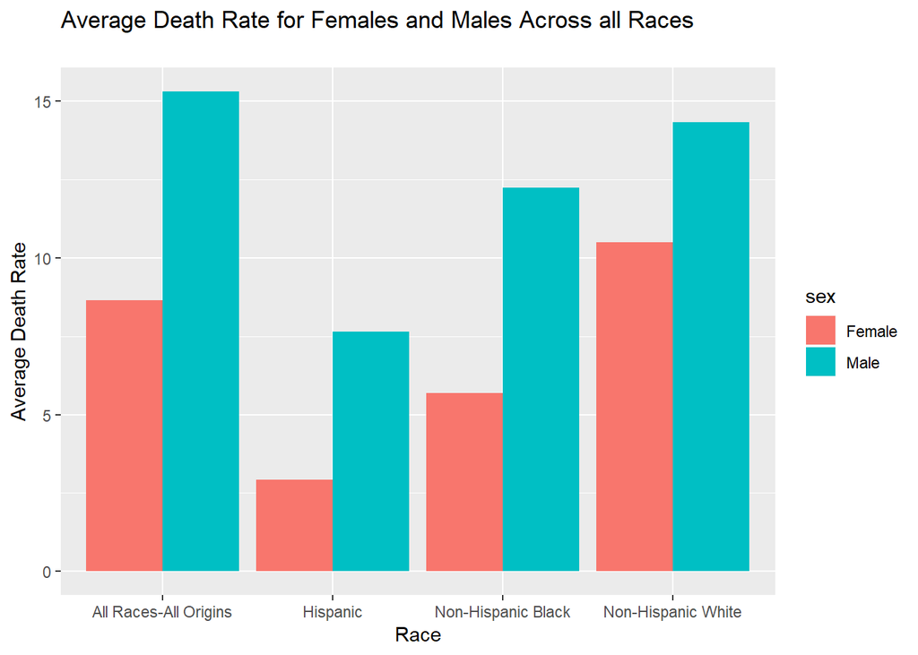

Each dot of the scatterplot below represents the population and drug deaths for an individual year of obtained data. It is evident that for each year of data males have a siginifcantly higher number of drug deaths than that of females.

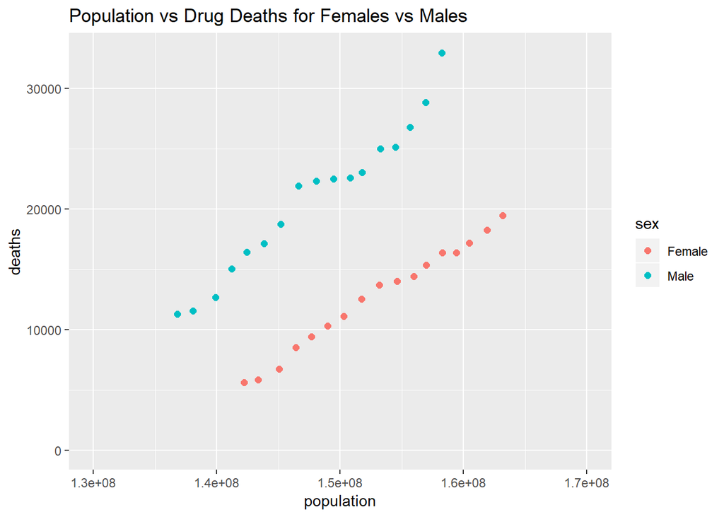